# espresso

31-Mar-2022: espresso 1.0.1 released.

`espresso` is a package for domain estimation of cells only from gene expression profile based on graph-structured stochastic self-organizing map (GraphSOM) and Markov chain Monte Carlo (MCMC) method.

# Table of Contents

- Installation
- Confirmed version
- Quick example
- Usage
  - Data format
  - Initialization of eSPRESSO object
  - Preprocessing (Optional)
    - Log-scaling
    - Gene filtering
  - GraphSOM clustering
  - Feature gene selection based on random forest
  - Usage of Gene Ontology (GO) information (optional)
  - Gene set optimization by replica exchange Markov chain Monte Carlo method (RX-MCMC)
  - Plot distance maps
  - Compute and plot UMAP
    - Other options of UMAP plotting
  - Appendix
    - Run `graphSOM` and `rxmcmc` of previous version (0.2.17)
    - Get gene description via biomaRt
- Citing `espresso`

# Installation

`espresso` can be installed by the following command.

```r
# Installation (X.X.X is a version number)
install.packages("espresso-X.X.X.tar.gz", repos = NULL, type = "source")
```

If an error message “ERROR: dependencies ‘XXX’ are not available for package ‘espresso’” is displayed in the installation step, please try to install required packages, which are listed as follows.

**CRAN packages**

- igraph
- mclust
- progress
- uwot
- rgl
- rFerns
- Boruta
- doParallel
- foreach
- pheatmap
- RColorBrewer
- scatterplot3d
- tagcloud
- plotrix

```r
# Installation example of CRAN packages
install.packages(c("igraph", "mclust", "progress", "uwot", "rgl",
                   "rFerns", "Boruta", "doParallel", "foreach", "pheatmap",
                   "RColorBrewer", "scatterplot3d", "tagcloud", "plotrix"),
                 dependencies = TRUE)
```

**Bioconductor packages**

- biomaRt
- GO.db

```r
# Installation example of Bioconductor packages
if (!requireNamespace("BiocManager", quietly = TRUE))
    install.packages("BiocManager")

BiocManager::install(c("biomaRt","GO.db"))
```

**Note**

If you try to install or load `espresso` on a machine that does not have X11, a warning message will be displayed because `rgl` package requires X11 to be installed. In such case, install X11, or ignore the warning if you do not need UMAP plots.

**Altanative**

`espresso` can be installed directly from Github repository, if `devtools` is installed.

```r
library(devtools)
install_github("tmorikuicr/espresso")
```

# Confirmed version

This vignette was generated by the following versions of R and packages.

```r
version
```

```
#>                _
#> platform       x86_64-apple-darwin17.0
#> arch           x86_64
#> os             darwin17.0
#> system         x86_64, darwin17.0
#> status
#> major          4
#> minor          0.3
#> year           2020
#> month          10
#> day            10
#> svn rev        79318
#> language       R
#> version.string R version 4.0.3 (2020-10-10)
#> nickname       Bunny-Wunnies Freak Out
```

```r
packageVersion("igraph")
```

```
#> [1] '1.2.11'
```

```r
packageVersion("mclust")
```

```
#> [1] '5.4.9'
```

```r
packageVersion("progress")
```

```
#> [1] '1.2.2'
```

```r
packageVersion("uwot")
```

```
#> [1] '0.1.11'
```

```r
packageVersion("rgl")
```

```
#> [1] '0.108.3'
```

```r
packageVersion("rFerns")
```

```
#> [1] '5.0.0'
```

```r
packageVersion("Boruta")
```

```
#> [1] '7.0.0'
```

```r
packageVersion("doParallel")
```

```
#> [1] '1.0.17'
```

```r
packageVersion("foreach")
```

```
#> [1] '1.5.2'
```

```r
packageVersion("pheatmap")
```

```
#> [1] '1.0.12'
```

```r
packageVersion("RColorBrewer")
```

```
#> [1] '1.1.2'
```

```r
packageVersion("scatterplot3d")
```

```
#> [1] '0.3.41'
```

```r
packageVersion("tagcloud")
```

```
#> [1] '0.6'
```

```r
packageVersion("plotrix")
```

```
#> [1] '3.8.2'
```

```r
packageVersion("biomaRt")
```

```
#> [1] '2.46.3'
```

```r
packageVersion("GO.db")
```

```
#> [1] '3.12.1'
```

Note that some versions of R may not be consistent with the `biomaRt` and `dplyr` pacakages. In such case, please install the above versions or updates R and the packages.

# Quick example

`espresso` can be easily executed by a few functions. Here, the most simple code is shown in the following, assuming that a gene expression profile `exprs`, a domain topology `topology`, and a domain assignment `asgmt` are already defined. The details of these inputs are explained in Data format.

```r
library(espresso)

# Initialize espresso object
eobj <- initEsp(exprs, topology, asgmt)

# GraphSOM clustering
eobj <- initGraphSOM(eobj)
eobj <- graphSOM(eobj)

# Show prediction scores
eobj@summary
```

If you need more details of the `espresso` functions, refer to the following sections and help manuals by `help` function (e.g., `help(espresso)`, `help(graphSOM)` etc.)

# Usage

## Data format

`espresso` requires three inputs, i.e., expression profile, domain topology, and domain assignment information for cell samples.

- **Expression profile** `exprs`  
  The expression profile is given as a numeric matrix whose rows and columns indicate cell samples and genes, respectively.

|  | Gene 1 | Gene 2 | Gene 3 | … |
| --- | --- | --- | --- | --- |
| Cell 1 | 0.15 | 0.28 | 1.33 | … |
| Cell 2 | 1.08 | 0.62 | 0.01 | … |
| Cell 3 | 0.74 | 0.42 | 0.87 | … |
| … | … | … | … | … |

- **Domain topology** `topology`  
  The domain topology is given as an adjacent matrix whose rows and columns indicate domains. In this matrix, `1` and `0` mean that corresponding domains are connected (i.e., adjacent each other in living a tissue or an organ) and unconnected, respectively. Note that this matrix must be symmetric and its diagonals must be filled by `0` since self-loops are not assumed in `espresso`.

|  | Domain 1 | Domain 2 | Domain 3 | Domain 4 |
| --- | --- | --- | --- | --- |
| Domain 1 | 0 | 1 | 1 | 0 |
| Domain 2 | 1 | 0 | 1 | 1 |
| Domain 3 | 1 | 1 | 0 | 1 |
| Domain 4 | 0 | 1 | 1 | 0 |

- **Domain assignment** `asgmt`  
  The Domain assignment is given as a `data.frame` with two columns which indicate cell samples and corresponding domains.

| sample | domain |
| --- | --- |
| Cell 1 | Domain 1 |
| Cell 2 | Domain 2 |
| Cell 3 | Domain 1 |
| Cell 4 | Domain 4 |
| … | … |

`espresso` contains example inputs of raw datasets for the above three inputs: “exprs_soysa19_e825.txt”, “topology_soysa19_e825.txt”, and “asgmt_soysa19_e825.txt”, which can be loaded by the following commands. The expression profile “exprs_soysa19_e825.txt” was created from [GSE126128_E775E825_WTKO_10X.csv.gz](https://www.ncbi.nlm.nih.gov/geo/query/acc.cgi?acc=GSE126128) by random selection of 10 single-cells from each domain i.e., 70 cell-samples in total.

```r
# Get paths of input files
path_exprs <- system.file("extdata", "exprs_soysa19_e825.txt", package = "espresso")
path_topology <- system.file("extdata", "topology_soysa19_e825.txt", package = "espresso")
path_asgmt <- system.file("extdata", "asgmt_soysa19_e825.txt", package = "espresso")

# Load data
exprs <- t(read.table(path_exprs, header = TRUE, row.names = 1, sep = "\t",
                      as.is = TRUE, check.names = FALSE))
topology <- as.matrix(read.table(path_topology, header = T, row.names = 1))
asgmt <- read.table(path_asgmt, header = T, as.is = TRUE)

# Show the contents of the objects
exprs[1:5, 1:5]
```

```
#>                     0610005C13Rik 0610007P08Rik 0610007P14Rik 0610007P22Rik
#> TGCCCATGTGCTGTAT-9              0     0.0000000     0.0000000     0.0000000
#> GCTGCGAAGGTGCAAC-10             0     0.0000000     0.5096020     0.8455493
#> CATCGAAAGTGTCCAT-10             0     0.0000000     0.0000000     0.4440263
#> GAACGGATCTGATTCT-10             0     0.3703834     0.6400520     0.3703834
#> ACTGCTCTCATTGCCC-10             0     0.0000000     0.6228278     0.8312940
#>                     0610008F07Rik
#> TGCCCATGTGCTGTAT-9              0
#> GCTGCGAAGGTGCAAC-10             0
#> CATCGAAAGTGTCCAT-10             0
#> GAACGGATCTGATTCT-10             0
#> ACTGCTCTCATTGCCC-10             0
```

```r
topology
```

```
#>        AHF OFT RV LV Atrial SV pSHF
#> AHF      0   1  0  0      0  0    1
#> OFT      1   0  1  0      0  0    0
#> RV       0   1  0  1      0  0    0
#> LV       0   0  1  0      1  0    0
#> Atrial   0   0  0  1      0  1    0
#> SV       0   0  0  0      1  0    1
#> pSHF     1   0  0  0      0  1    0
```

```r
head(asgmt)
```

```
#>                sample domain
#> 1  TGCCCATGTGCTGTAT-9 Atrial
#> 2 GCTGCGAAGGTGCAAC-10 Atrial
#> 3 CATCGAAAGTGTCCAT-10 Atrial
#> 4 GAACGGATCTGATTCT-10 Atrial
#> 5 ACTGCTCTCATTGCCC-10 Atrial
#> 6 AAGGAGCTCATACGGT-10 Atrial
```

## Initialization of eSPRESSO object

Before executing GraphSOM clustering, `espresso` object should be prepared. The variables `exprs`, `topology`, and `asgmt` are inputs explained in Data format. `initEsp` is a function to initialize and return an `espresso` object.

```r
eobj <- initEsp(exprs, topology, asgmt)
```

The `espresso` object is defined as `S4` class, and its slots can be accessed by `@` symbol.

```r
str(eobj)
```

```
#> Formal class 'Espresso' [package "espresso"] with 28 slots
#>   ..@ exprs      : num [1:70, 1:23749] 0 0 0 0 0 0 0 0 0 0 ...
#>   .. ..- attr(*, "dimnames")=List of 2
#>   .. .. ..$ : chr [1:70] "TGCCCATGTGCTGTAT-9" "GCTGCGAAGGTGCAAC-10" "CATCGAAAGTGTCCAT-10" "GAACGGATCTGATTCT-10" ...
#>   .. .. ..$ : chr [1:23749] "0610005C13Rik" "0610007P08Rik" "0610007P14Rik" "0610007P22Rik" ...
#>   ..@ exprs_som  : NULL
#>   ..@ rept_som   : NULL
#>   ..@ topology   : int [1:7, 1:7] 0 1 0 0 0 0 1 1 0 1 ...
#>   .. ..- attr(*, "dimnames")=List of 2
#>   .. .. ..$ : chr [1:7] "AHF" "OFT" "RV" "LV" ...
#>   .. .. ..$ : chr [1:7] "AHF" "OFT" "RV" "LV" ...
#>   ..@ dist       : NULL
#>   ..@ map        : NULL
#>   ..@ map_method : NULL
#>   ..@ radius     : NULL
#>   ..@ lsteps     : NULL
#>   ..@ rept       : NULL
#>   ..@ bmu        : NULL
#>   ..@ bmu_method : NULL
#>   ..@ stochastic : NULL
#>   ..@ rmin       : NULL
#>   ..@ rmax       : NULL
#>   ..@ domain2name:'data.frame':  7 obs. of  2 variables:
#>   .. ..$ domain: int [1:7] 1 2 3 4 5 6 7
#>   .. ..$ name  : chr [1:7] "AHF" "OFT" "RV" "LV" ...
#>   ..@ gset       : chr [1:23749] "0610005C13Rik" "0610007P08Rik" "0610007P14Rik" "0610007P22Rik" ...
#>   ..@ ssets      : NULL
#>   ..@ asgmt      :'data.frame':  70 obs. of  2 variables:
#>   .. ..$ sample: chr [1:70] "TGCCCATGTGCTGTAT-9" "GCTGCGAAGGTGCAAC-10" "CATCGAAAGTGTCCAT-10" "GAACGGATCTGATTCT-10" ...
#>   .. ..$ domain: chr [1:70] "Atrial" "Atrial" "Atrial" "Atrial" ...
#>   ..@ score      : NULL
#>   ..@ summary    : NULL
#>   ..@ mcmc       : NULL
#>   ..@ seed       : NULL
#>   ..@ coef       : NULL
#>   ..@ nmin       : NULL
#>   ..@ nmax       : NULL
#>   ..@ swap       : NULL
#>   ..@ umap       : NULL
```

## Preprocessing (Optional)

`espresso` provides simple preprocessing functions for log-scaling of expression profile and filtering out of low expressed and low variable genes. If the input expression profile need not be preprocessed, this procedure can be ignored.

### Log-scaling

The input gene expression data can be scaled by log10 as preprocessing. The base can be changed by specifying `base = "2"` or `base = "e"`.

```r
# Log-scaling of the expression profile
# In this example, log-scaling is unnecessary since the expression values is already log-scaled.
# eobj <- logScale(eobj)
```

### Gene filtering

The low expressed and low variable genes can be filtered out by the following command. As default setting, genes with expression level of higher than 1 in at least two cells and whose standard deviation of expression levels through all cells more than 0.05 can pass the filtering.

```r
# Filter out genes with low expression and low variance
eobj <- filterGenes(eobj)
```

```
#> Filtering genes...
#> 19699 genes are filtered out (23749 -> 4050 genes).
```

The parameters can be changed by specifying the arguments `ncell`, `expressed`, and `sd`, i.e., the default setting is `ncell = 2`, `expressed = 1.0`, and `sd = 0.05`.

```r
# Filter out genes with low expression and low variance
eobj <- filterGenes(eobj, ncell = 2, expressed = 1.0, sd = 0.05)
```

## GraphSOM clustering

Before starting GraphSOM clustering, the parameters for GraphSOM clustering should be initialized.

```r
eobj <- initGraphSOM(eobj)
```

In this case, all cell samples and genes are used for the clustering, so that it will take a long time to execute when the input gene expression profile is quite large.

Therefore, if downsampling is required, `graphSOM` can be executed with subsets of cell samples selected uniformly random from each domain, and repeats the clustering with different sets. The `nsamples` indicates the number of samples extracted from each domain, i.e., `nsamples = 10` under a dataset with 4 domains means that 40 cell samples will be selected. If the total number of samples of a certain domain is less than the value specified `nsamples`, all samples of the domain are selected. The `rept` is the number of repeats for GraphSOM clustering with different sample sets.

In addition, the `coef` is the coefficient of ARI value for score function. The GraphSOM results are evaluated by prediction accuracy, ARI, and a score function (= accuracy + `coef` * ARI). The default is `coef = 1.0`.

```r
eobj <- initGraphSOM(eobj, nsamples = 10, coef = 0.5, rept = 3)
```

If the sample set after downsampling needs to be fixed, set a value to the parameter `seed`.

**Note**

Even if the same random seed is given, the selected samples may differ depending on the version of R.

```r
eobj <- initGraphSOM(eobj, nsamples = 10, coef = 0.5, rept = 3, seed = 0)
```

From the version 0.2.8, GraphSOM clustering introduces the cluster swap method by default. If the cluster swap method is not needed, set `FALSE` to the option `swap` of `initGraphSOM` function.

```r
eobj <- initGraphSOM(eobj, nsamples = 10, coef = 0.5, rept = 3, swap = FALSE, seed = 0)
```

After initializing GraphSOM setting, GraphSOM can be executed. The most simple way to execute GraphSOM clustering under the parameter setting given by `initGraphSOM` is as follow.

```r
eobj <- graphSOM(eobj)
```

As another option, `graphSOM` can be executed with a specific gene set by setting it to the parameter `gset` as a `vector`.

```r
eobj <- graphSOM(eobj, gset = c("Actn2", "Hand2", "Vegfb", "Wnt5a"))
```

```
#> GraphSOM clustering
#> Evaluation
#> Complete
```

In addition to these, `graphSOM` has several parameters, so please refer to the manual for their details.

The `graphSOM` clustering results can be shown by the following.

```r
eobj@summary
```

```
#> $mean_score
#> [1] 0.7205172
#>
#> $var_score
#> [1] 0.0004588838
#>
#> $max_score
#> [1] 0.7446825
#>
#> $min_score
#> [1] 0.7038614
#>
#> $mean_acc
#> [1] 0.6270531
#>
#> $var_acc
#> [1] 6.521239e-05
#>
#> $max_acc
#> [1] 0.6351967
#>
#> $min_acc
#> [1] 0.6190476
#>
#> $mean_ari
#> [1] 0.1869282
#>
#> $var_ari
#> [1] 0.0007717202
#>
#> $max_ari
#> [1] 0.2189716
#>
#> $min_ari
#> [1] 0.1696275
```

The results are mean values and mean variance of the score, the prediction accuracy, and ARI for the repeats specified in `graphSOM` function. The result of each repeat can also be shown.

```r
eobj@score
```

```
#>            score       acc       ari
#> rept.1 0.7130078 0.6269151 0.1721854
#> rept.2 0.7038614 0.6190476 0.1696275
#> rept.3 0.7446825 0.6351967 0.2189716
```

The convergence curve can be shown. `rept` indicates the repeat numbers to be plotted.

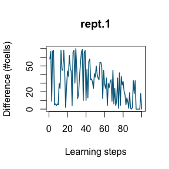

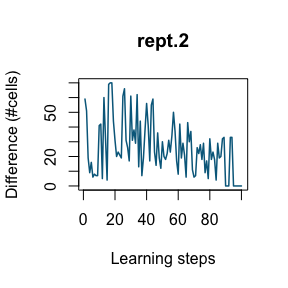

```r
plotConvCurve(eobj, rept = 1:2)
```

The multiple results are plotted at the same time by the following example code.

```r
par(mfrow = c(2,2))
plotConvCurve(eobj)
dev.off()
```

## Feature gene selection based on random forest

`espresso` provides a function for feature gene selection `selectFeatures`. This function is a rapper function of `Boruta` function of `Boruta` package, which is a feature gene selection method based on random forest. The usage of this function is very simple.

```r
fgenes <- selectFeatures(eobj, maxRuns = 100)

fgenes
```

```
#>  [1] "Mylk3"         "Ncl"           "Ptma"          "Tnni1"
#>  [5] "Actc1"         "Ak1"           "Apoe"          "Cryab"
#>  [9] "Csrp2"         "Cst3"          "Fbxl22"        "Fbxo32"
#> [13] "Hspb2"         "Myh7"          "Myl3"          "Myl4"
#> [17] "Myl7"          "Pgam2"         "Pkm"           "Slc25a4"
#> [21] "Tagln"         "Tmod1"         "Tnni3"         "Tpi1"
#> [25] "Tpm1"          "Tuba1a"        "Actn2"         "Atp5c1"
#> [29] "Hcfc1r1"       "Myl1"          "Myl6"          "Npm3"
#> [33] "Tgfb1i1"       "Bnip3"         "Crip1"         "Gyg"
#> [37] "Hmgb1"         "Dlk1"          "Hspe1"         "Ldha"
#> [41] "Pdlim1"        "Pdlim5"        "Ptpla"         "Marcksl1"
#> [45] "Naca"          "Rps7"          "Atp5o"         "Gm10075"
#> [49] "Apobec2"       "Isl1"          "Lta4h"         "Actb"
#> [53] "Atp2a2"        "Dcp1b"         "Itga6"         "Nr2f2"
#> [57] "Anxa2"         "Cox6a2"        "Rassf5"        "Tdgf1"
#> [61] "Wbp5"          "Suclg2"        "Tkt"           "Krt19"
#> [65] "Lrrc39"        "Nop16"         "Atp5g1"        "Rpl7a"
#> [69] "Rplp2"         "Cdh2"          "Hnrnpab"       "Fundc2"
#> [73] "4833424O15Rik" "Ndufs6"
```

Please note that the result of `Boruta` depends on random seed. Thus, if the results need to be fixed, set a value to the parameter `seed`.

```r
fgenes <- selectFeatures(eobj, maxRuns = 100, seed = 0)
```

`Boruta` classifies genes into the three categories, “Confirmed”, “Tentative”, and “Rejected”, according to their importance. This function returns a vector of “NOT Rejected” genes as features by default. If only “Confirmed” genes are required, set `"c"` to the parameter `decision`.

```r
fgenes <- selectFeatures(eobj, maxRuns = 100, decision = "c", seed = 0)
```

In order to resolve genes left as “Tentative”, `maxRuns` may be increased, where the parameter `maxRuns` is the maximum number of importance source runs (refer the manual of `Boruta` package). Empirically, it is good to determine the parameters so that around 100 genes are selected.

## Usage of Gene Ontology (GO) information (optional)

In order to execute `graphSOM` with functional gene sets already defined, `espresso` provides us with gene sets in GO database.

```r
# Mouse gene sets (Ensembl release version 101)
data(mm_symbol_v101)

# Human gene sets (Ensembl release version 101)
data(hs_symbol_v101)
```

If another version, another species, or another gene identifier are required, the following command enable a user to create another gene set via R `biomaRt` package. The parameters to be set to `species` are `gid` according to `biomaRt`. Note that if the latest version is required, please do not specify `version` in the function.

```r
# Get GO information
hs_symbol_v98 <- getGO(species = 'hsapiens', gid = 'hgnc_symbol', version = '98')

# Save 'hs_symbol_v98' as an R data file.
save(hs_symbol_v98, file = "hs_symbol_v98")

# Load 'hs_symbol_v98'
load(hs_symbol_v98)
```

The GO information are stored as a list, and each element of list has two vectors, `term` and `genes`.

```r
mm_symbol_v101[["GO:0003209"]][["term"]]
```

```
#> [1] "cardiac atrium morphogenesis"
```

```r
mm_symbol_v101[["GO:0003209"]][["genes"]]
```

```
#>  [1] "Acvr1"  "Bmp10"  "Bmpr2"  "Ccm2l"  "Ccn1"   "Cfc1"   "Dll4"   "Eng"
#>  [9] "Gata4"  "Gja5"   "Heg1"   "Hey2"   "Isl1"   "Mesp1"  "Myh6"   "Nkx2-5"
#> [17] "Nog"    "Notch1" "Notch2" "Nsd2"   "Pitx2"  "Prox1"  "Shox2"  "Smo"
#> [25] "Sos1"   "Sox4"   "Tbx20"  "Tbx5"   "Tgfb2"  "Tnnt2"  "Wnt2"   "Wnt5a"
#> [33] "Zfpm1"
```

Thus, `graphSOM` execution using GO genes can be done by

```r
eobj <- graphSOM(eobj, gset = mm_symbol_v101[["GO:0003209"]][["genes"]])
```

## Gene set optimization by replica exchange Markov chain Monte Carlo method (RX-MCMC)

`espresso` optimizes gene sets by replica exchange Markov chain Monte Carlo method (RX-MCMC). The parameters `itr`, `n_ex`, and `n_repl` are the number of iterations of MCMC until each replica exchange, the number of times of exchanges, and the number of replicas, respectively. Thus, the total number of MCMC steps is `itr * n_ex`. If the user’s machine has multi-core processors, the MCMC computations of each replica are parallelized.

```r
eobj <- initGraphSOM(eobj, nsamples = 10, rept = 1, coef = 0.5)
eobj <- rxmcmc(eobj, gset = fgenes, itr = 2, n_ex = 5, n_repl = 4)
```

Although the number of cores is automatically detected, it can be specified by `n_cl`. In addition, as the default setting, MCMC optimizations are started with 3 genes randomly selected from the gene set specified by `gset`. However it can be also modified by `n_ig`. Note that the length of `fgenes` must be larger than `n_ig`.

```r
eobj <- rxmcmc(eobj, gset = fgenes, itr = 2, n_ex = 5, n_repl = 4, n_cl = 4, n_ig = 3)
```

The random seed can be fixed by the `seed` option in the `rxmcmc` function.

```r
eobj <- rxmcmc(eobj, gset = fgenes, itr = 2, n_ex = 5, n_repl = 4, n_cl = 4, n_ig = 3, seed = 0)
```

The results of RX-MCMC are stored in `espresso` objects and they can be accessed by `@mcmc`.

- `eobj@mcmc[["sampling"]]`: History of sampling
- `eobj@mcmc[["max"]]`: History of the samples with the best score
- `eobj@mcmc[["exchange"]]`: History of replica exchange
- `eobj@mcmc[["final_genes"]]`: The final genes for each replicas
- `eobj@mcmc[["best_repl"]]`: Information of the best replicas
- `eobj@mcmc[["best_genes"]]`: The best genes

```r
eobj@mcmc[["sampling"]][["repl.1"]]
```

[output not shown]

```r
eobj@mcmc[["max"]][["repl.1"]]
```

```
#>         mean_score var_score max_score min_score  mean_acc var_acc   max_acc
#> step.1   0.7840921        NA 0.7840921 0.7840921 0.6463768      NA 0.6463768
#> step.2   0.9046352        NA 0.9046352 0.9046352 0.7064182      NA 0.7064182
#> step.3   1.0212497        NA 1.0212497 1.0212497 0.7726708      NA 0.7726708
#> step.4   1.0885844        NA 1.0885844 1.0885844 0.7937888      NA 0.7937888
#> step.5   1.1324930        NA 1.1324930 1.1324930 0.8115942      NA 0.8115942
#> step.6   1.2182934        NA 1.2182934 1.2182934 0.8641822      NA 0.8641822
#> step.7   1.2907131        NA 1.2907131 1.2907131 0.9026915      NA 0.9026915
#> step.8   1.3779302        NA 1.3779302 1.3779302 0.9449275      NA 0.9449275
#> step.9   1.3779302        NA 1.3779302 1.3779302 0.9449275      NA 0.9449275
#> step.10  1.3779302        NA 1.3779302 1.3779302 0.9449275      NA 0.9449275
#>           min_acc  mean_ari var_ari   max_ari   min_ari gene_size
#> step.1  0.6463768 0.2754306      NA 0.2754306 0.2754306         3
#> step.2  0.7064182 0.3964340      NA 0.3964340 0.3964340         4
#> step.3  0.7726708 0.4971578      NA 0.4971578 0.4971578         5
#> step.4  0.7937888 0.5895911      NA 0.5895911 0.5895911         6
#> step.5  0.8115942 0.6417977      NA 0.6417977 0.6417977         7
#> step.6  0.8641822 0.7082224      NA 0.7082224 0.7082224         6
#> step.7  0.9026915 0.7760433      NA 0.7760433 0.7760433         7
#> step.8  0.9449275 0.8660054      NA 0.8660054 0.8660054         8
#> step.9  0.9449275 0.8660054      NA 0.8660054 0.8660054         8
#> step.10 0.9449275 0.8660054      NA 0.8660054 0.8660054         8
```

```r
eobj@mcmc[["exchange"]]
```

```
#>         repl.1 repl.2 repl.3 repl.4
#> step.1   1.000  0.100   0.01  0.001
#> step.2   1.000  0.010   0.10  0.001
#> step.3   1.000  0.010   0.10  0.001
#> step.4   0.100  0.001   1.00  0.010
#> step.5   0.100  0.001   1.00  0.010
#> step.6   0.010  0.001   1.00  0.100
#> step.7   0.010  0.001   1.00  0.100
#> step.8   0.001  0.010   1.00  0.100
#> step.9   0.001  0.010   1.00  0.100
#> step.10  0.001  0.100   1.00  0.010
```

```r
eobj@mcmc[["final_genes"]]
```

```
#> $repl.1
#> [1] "Rassf5" "Atp5o"  "Apoe"   "Dlk1"   "Tdgf1"  "Cryab"  "Tuba1a" "Pdlim1"
#>
#> $repl.2
#> [1] "Wbp5"    "Myl3"    "Actn2"   "Apoe"    "Dlk1"    "Csrp2"   "Slc25a4"
#> [8] "Hmgb1"   "Myl1"
#>
#> $repl.3
#>  [1] "Crip1"    "Hmgb1"    "Ptma"     "Apoe"     "Tdgf1"    "Fbxo32"
#>  [7] "Marcksl1" "Tpi1"     "Tuba1a"   "Myl6"     "Dlk1"     "Pdlim1"
#>
#> $repl.4
#>  [1] "Anxa2"   "Fbxl22"  "Apoe"    "Tuba1a"  "Tdgf1"   "Tpi1"    "Tgfb1i1"
#>  [8] "Slc25a4" "Bnip3"   "Pdlim1"
```

```r
eobj@mcmc[["best_repl"]]
```

```
#>   repl step
#> 1    1    8
```

```r
eobj@mcmc[["best_genes"]]
```

```
#> $repl.1
#> [1] "Rassf5" "Atp5o"  "Apoe"   "Dlk1"   "Tdgf1"  "Cryab"  "Tuba1a" "Pdlim1"
```

The results of RX-MCMC can be also obtained as text files as follows, where `dir` is a path to an output directory.

```r
writeMCMC(eobj, dir = "output")
```

The histories of RX-MCMC optimization and replica exchanges can be plotted by `plotMCMC` function.

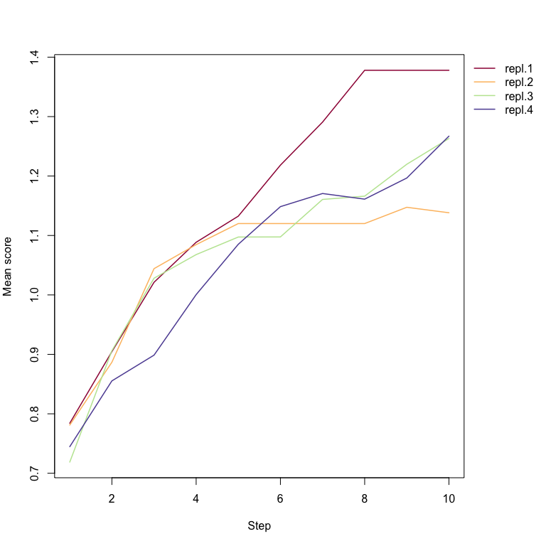

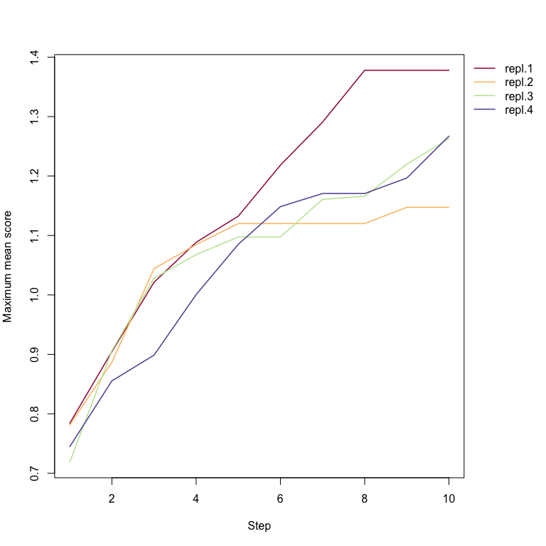

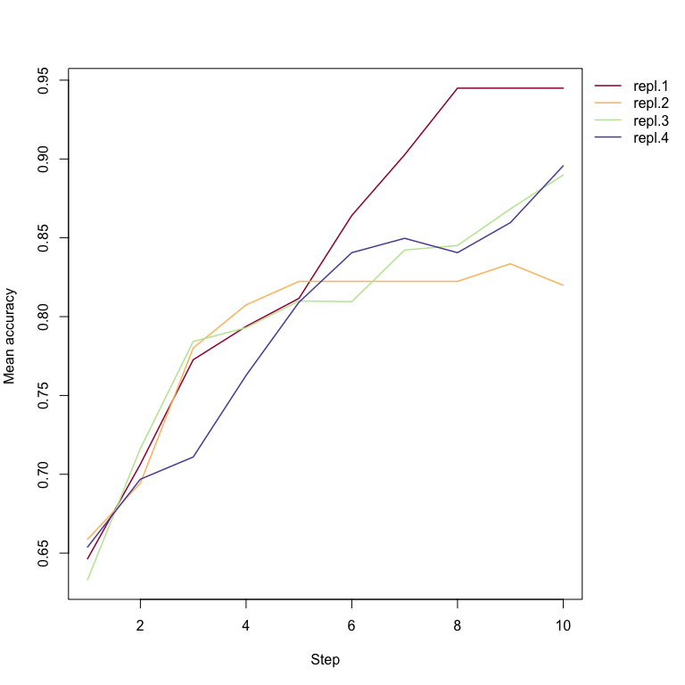

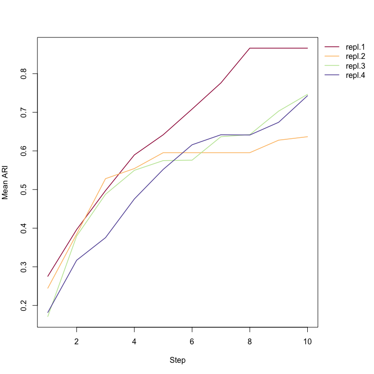

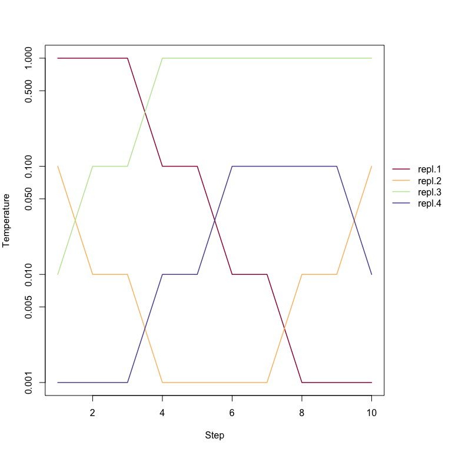

```r
plotMCMC(eobj)
```

## Plot distance maps

In order to visualize the distance between domains and between cell samples before/after clustering for all replications, `espresso` provides `plotDistMap`. The usage is quite simple.

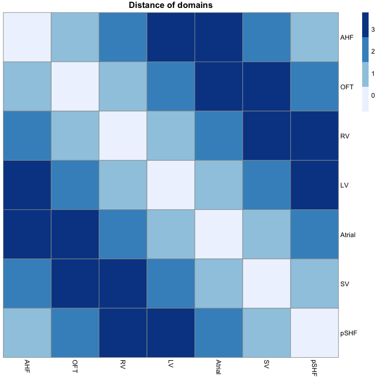

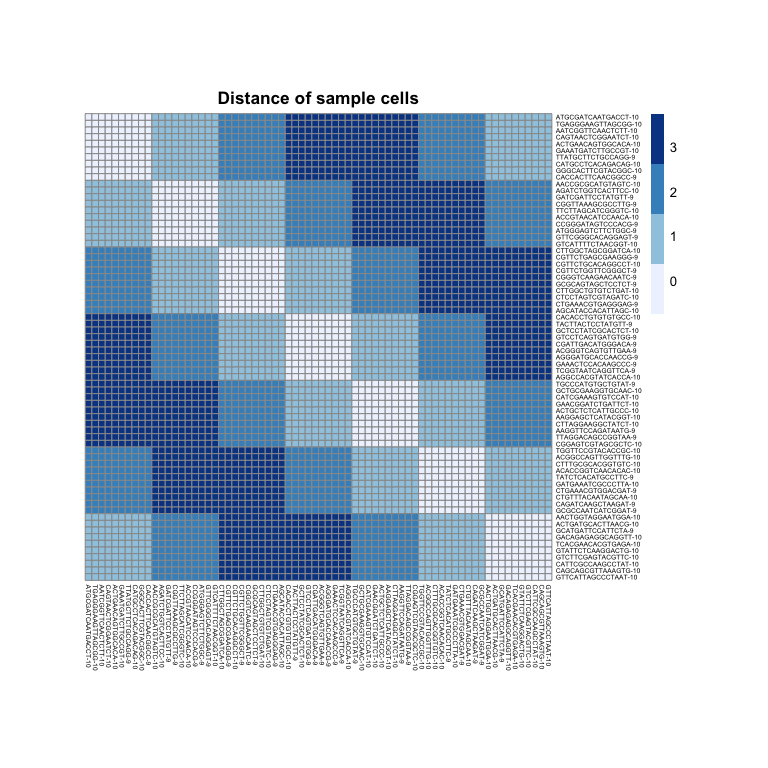

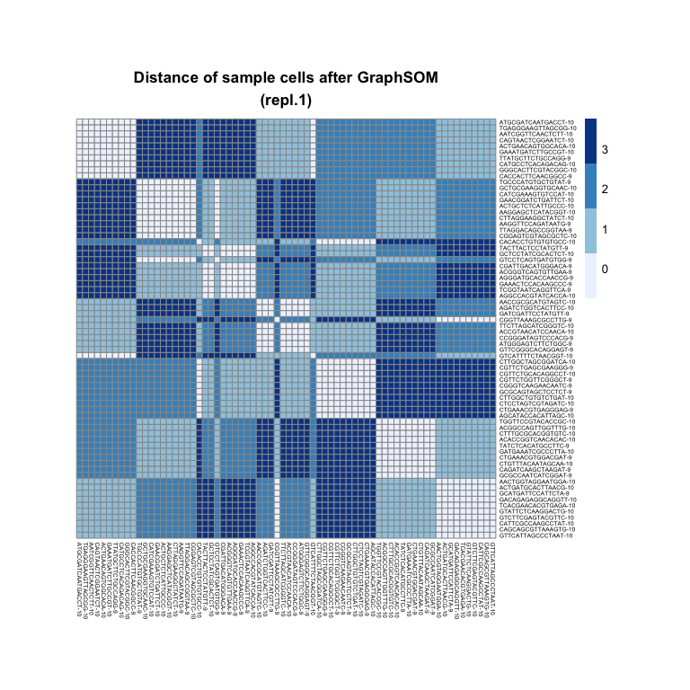

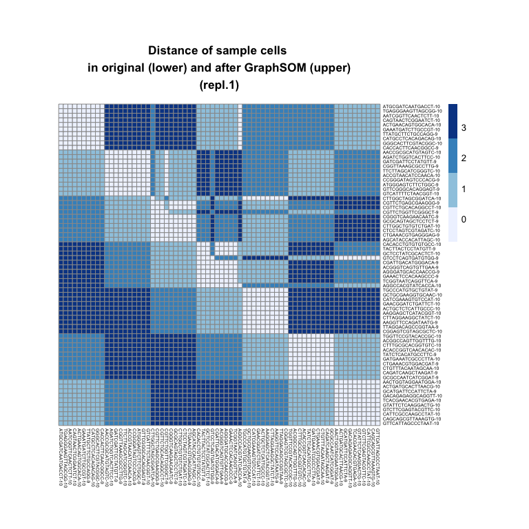

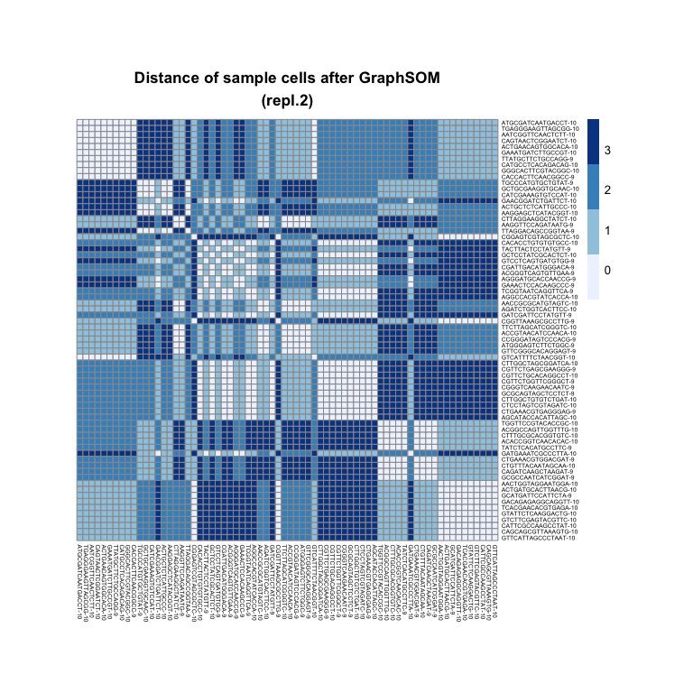

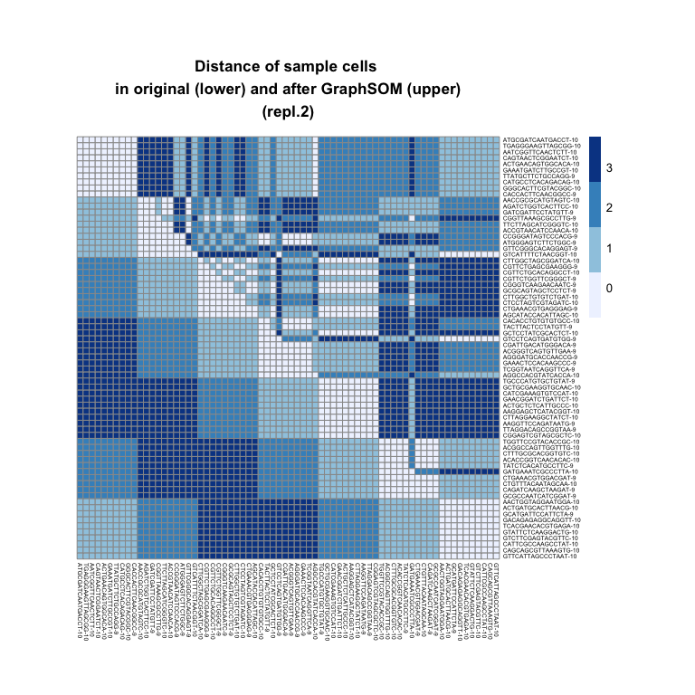

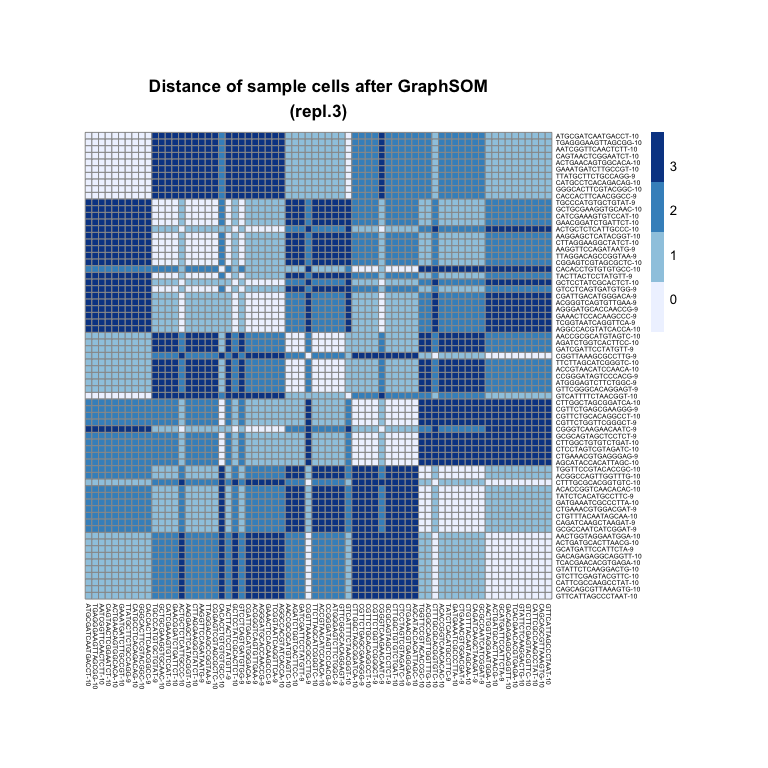

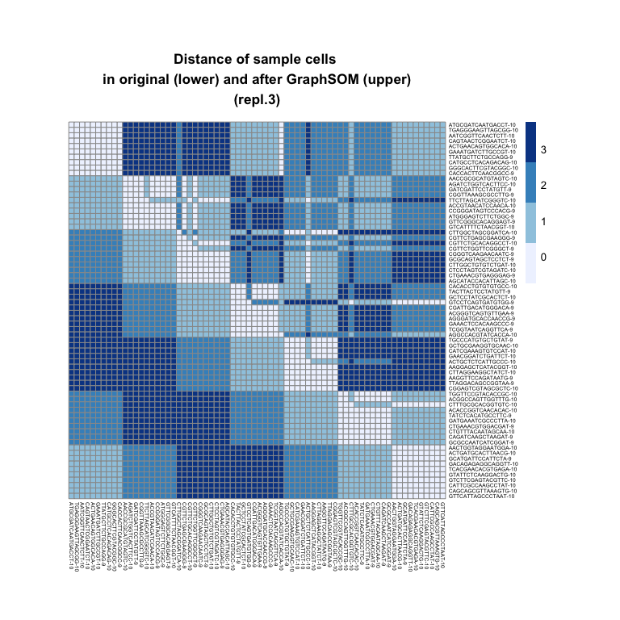

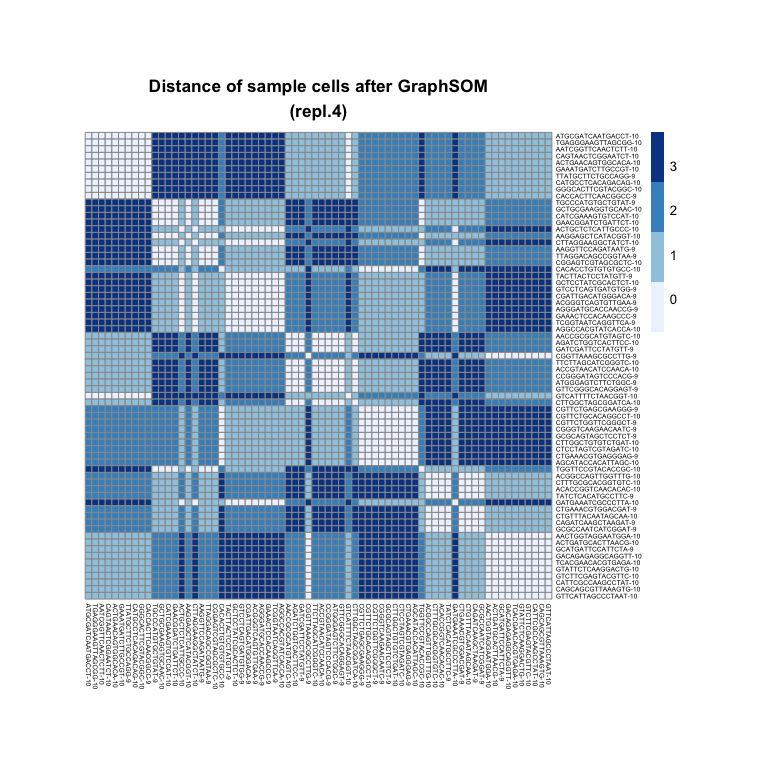

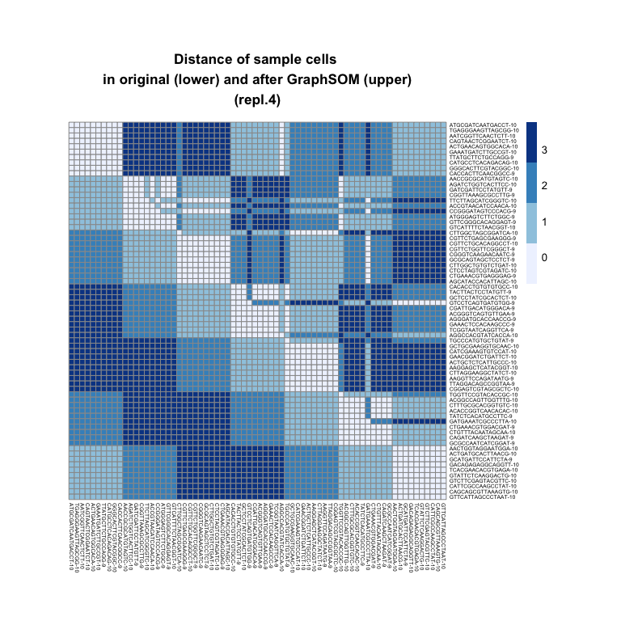

```r
# size_d: The font and cell sizes for distance map of domains (default: NULL).
# size_s: The font and cell sizes for distance map of cell samples (default: 5).
plotDistMap(eobj, size_s = 5)
```

## Compute and plot UMAP

`espresso` provides a function for dimension reduction method named Uniform Manifold Approximation and Projection (UMAP) to show the distribution of the cell samples in 2D or 3D space (the default space is 2D). To compute and plot UMAP, use `runUMAP` and `plotUMAP` functions, respectively. The UMAP result is stored `@umap`.

```r
eobj <- runUMAP(eobj)
head(eobj@umap)
```

```
#>                           [,1]       [,2]
#> TGCCCATGTGCTGTAT-9  -0.0225598 -2.2024913
#> GCTGCGAAGGTGCAAC-10  0.4925257  2.6053568
#> CATCGAAAGTGTCCAT-10  0.4897042 -2.5706015
#> GAACGGATCTGATTCT-10  0.7458983 -2.0646923
#> ACTGCTCTCATTGCCC-10 -0.8827290  1.5327852
#> AAGGAGCTCATACGGT-10  2.3228327 -0.6908234
```

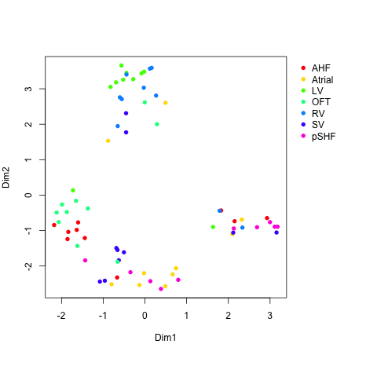

UMAP

```r
plotUMAP(eobj, file = 'umap_2D.png')
```

This function imports `uwot` packages, thus all parameters for UMAP computation can be given according to the original package. When using custom settings for UMAP, give the UMAP parameters `umap_param` as a list to `runUMAP` by the following way. For the details of the parameters, refer to `uwot::umap` function. The feature genes can be given by `gset` parameter while UMAP is performed with genes stored in `@gset` if `gset = NULL`.

```r
eobj <- runUMAP(eobj, gset = eobj@mcmc[["best_genes"]][[1]],
                umap_param = list("n_neighbors" = 15, "n_components" = 3, "n_epochs" = 1000))
head(eobj@umap)
```

```
#>                           [,1]      [,2]       [,3]
#> TGCCCATGTGCTGTAT-9  0.43003062 0.5923542 0.50436763
#> GCTGCGAAGGTGCAAC-10 0.31407598 0.1939962 0.55319766
#> CATCGAAAGTGTCCAT-10 0.03563408 0.8370204 0.18181876
#> GAACGGATCTGATTCT-10 0.23244337 1.1186721 0.43697814
#> ACTGCTCTCATTGCCC-10 0.44378451 0.9767128 0.29235486
#> AAGGAGCTCATACGGT-10 0.30735520 0.9815349 0.05170516
```

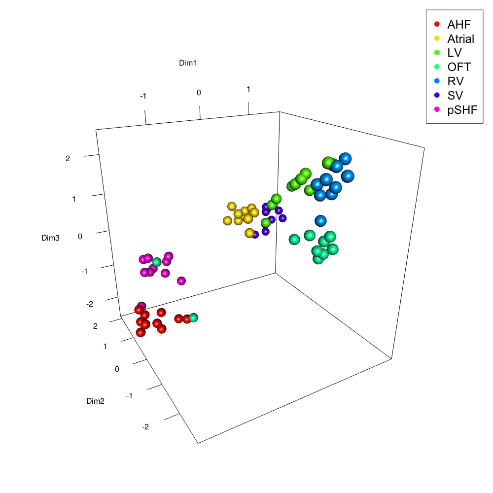

UMAP

```r
# size: the size for plotted points.
# magnify: Multiplicative factor to apply to size of window when producing legend (default: 1).
plotUMAP(eobj, size = 1.5, magnify = 1, file = "umap_3D.png")
```

Although the `plotUMAP` imports `rgl` package, `scatterplot3d` package can be used instead of `rgl` by `rgl = FALSE` (default: `TRUE`) when `rgl` is not available.

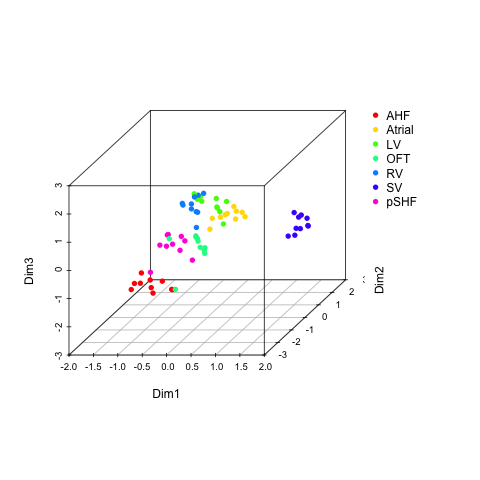

UMAP

```r
plotUMAP(eobj, file = "umap_3D_scatterplot.png", rgl = FALSE)
```

The export format is automatically detected from its extension (Supported: png, pdf, eps)

```r
plotUMAP(eobj, file = 'umap.pdf')
```

The RGL window can be closed after plotting by `rglclose = TRUE`.

```r
plotUMAP(eobj, file = 'umap.pdf', rglclose = TRUE)
```

The file saving can be suppress by `save = FALSE`. This is useful when you want to use `png()`, `pdf()`, and `postscript()` functions directly in order to specify their parameters (e.g., `width`, `height`, and so on) manually.

```r
pdf(file = 'umap.pdf', width = 6, height = 6)
plotUMAP(eobj, save = FALSE)
dev.off()
```

**Note**

When the exported format is ‘pdf’ or ‘eps’, and `rgl = TRUE`, the legend information is not printed due to the design of `rgl` package. In addition, it often takes much time to draw UMAP plot as a PDF file when the number of samples is large. In such case, please output as a PNG file.

### Other options of UMAP plotting

Plotting colors can be changed by any colors according to the domains.

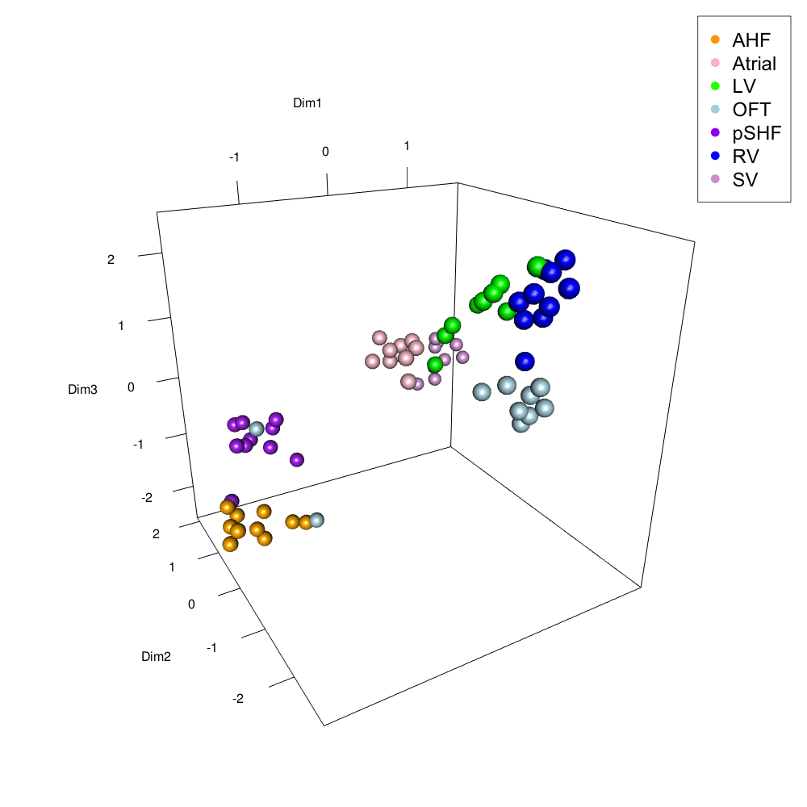

UMAP

```r
domain_colors <- list(AHF = "orange",
                      Atrial = "pink",
                      LV = "green",
                      OFT = "lightblue",
                      pSHF = "purple",
                      RV = "blue",
                      SV = "plum"
                      )
plotUMAP(eobj, domcol = domain_colors, file = "umap_3D_color1.png", size = 1.5)
```

Color coding in groups different from the domains is possible with the `color_by_group` and `grpcol` options. The `color_by_group` must be a `data.frame` of two columns with a header given by the following format, where the header must be ‘sample’ and ‘group’.

| sample | group |
| --- | --- |
| Cell 1 | Group 1 |
| Cell 2 | Group 2 |
| Cell 3 | Group 1 |
| Cell 4 | Group 4 |
| … | … |

The color of each group can be specified by `grpcol` of the same format as `domcol`. The following is an example.

```r
path_group <- system.file("extdata", "group_soysa19_e825.txt", package = "espresso")
group <- read.table(path_group, header = T, as.is = TRUE)
head(group)
```

```
#>                sample group
#> 1  TGCCCATGTGCTGTAT-9   FHF
#> 2 GCTGCGAAGGTGCAAC-10   FHF
#> 3 CATCGAAAGTGTCCAT-10   FHF
#> 4 GAACGGATCTGATTCT-10   FHF
#> 5 ACTGCTCTCATTGCCC-10   FHF
#> 6 AAGGAGCTCATACGGT-10   FHF
```

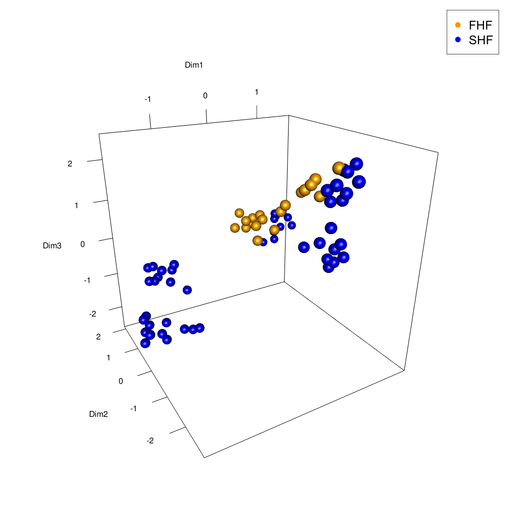

UMAP

```r
group_colors <- list(FHF = "orange", SHF = "blue")
plotUMAP(eobj, color_by_group = group, grpcol = group_colors, size = 1.5, file = "umap_3D_color2.png")
```

In addition, the coloring of each sample can also be based on the expression levels of a gene rather than the domains by specifying a gene name to the argument `color_by_gene`. In such case, the `domcol` is ignored.

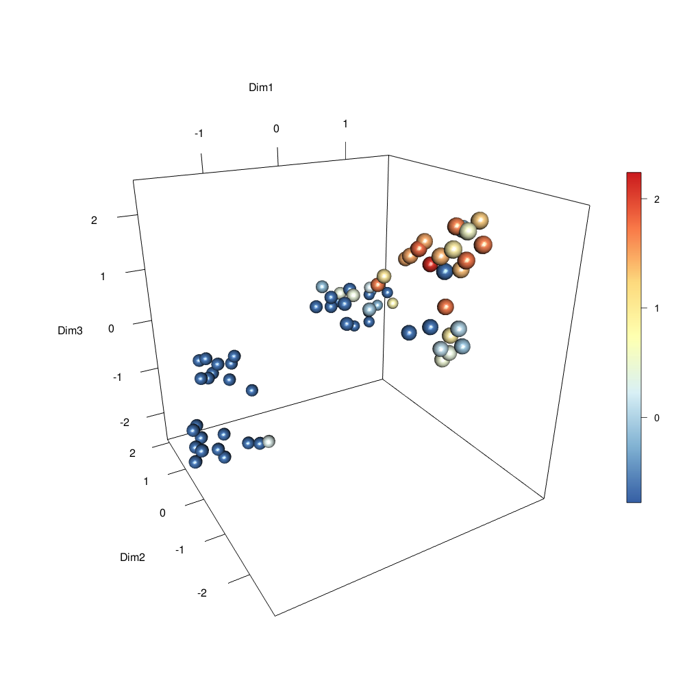

UMAP

```r
plotUMAP(eobj, color_by_gene = "Actn2", file = "umap_3D_color3.png", size = 1.5)
```

If `movie = TRUE`, a movie of the resulting UMAP is generated. This option is valid when `rgl = TRUE`.

```r
plotUMAP(eobj, movie = TRUE)
```

The above script uses all cell samples for UMAP plotting. If you want to plot UMAP with downsampled sets, the following script can work.

```r
eobj.tmp <- eobj
samples <- eobj.tmp@ssets[["set.1"]]
eobj.tmp@exprs <- eobj.tmp@exprs[match(samples, rownames(eobj.tmp@exprs)), , drop = FALSE]
eobj.tmp <- runUMAP(eobj.tmp, gset = eobj.tmp@mcmc[["best_genes"]][[1]],
                    umap_param = list("n_neighbors" = 5, "n_components" = 3, "n_epochs" = 1000))
plotUMAP(eobj.tmp, movie = TRUE, domcol = domain_colors)
```

UMAP is even more effective for overviewing distribution of cell samples when the number of cell samples is large. The following figure is UMAP using GO:0003209 for 3,331 cell samples obtained from [GSE126128_E775E825_WTKO_10X.csv.gz](https://www.ncbi.nlm.nih.gov/geo/query/acc.cgi?acc=GSE126128).

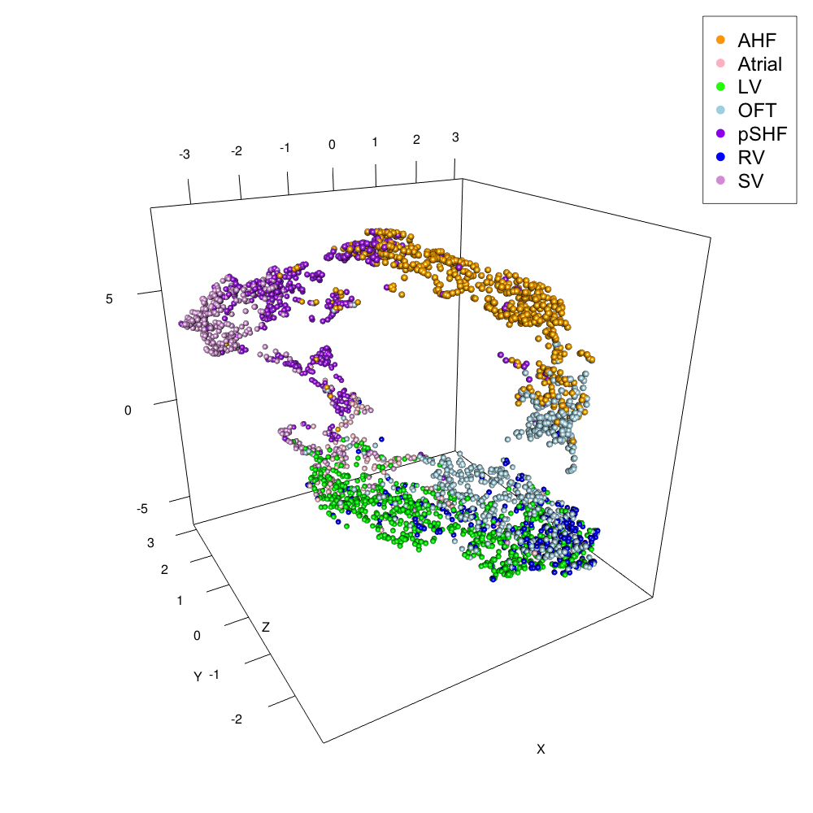

UMAP

## Appendix

In `espresso` of version 0, the reproducibility between the results of `graphSOM` and `rxmcmc` was not guaranteed, and a random number generation method different from version 1.0.0 or later was employed. The followings are examples of the way to run `graphSOM` and `rxmcmc` of version 0.

```r
graphSOM(eobj, gset = fgenes, seed = 0, version = "0")
```

```r
rxmcmc(eobj, gset = fgenes, itr = 2, n_ex = 5, n_repl = 4, n_cl = 4, seed = 0, version = "0")
```

### Get gene description via biomaRt

The gene description can be obtained via `biomaRt` package as followings:

```r
library(biomaRt)
fgenes <- c("Actn2", "Hand2", "Vegfb", "Wnt5a")
ds <- useEnsembl(biomart = 'ensembl', dataset = 'mmusculus_gene_ensembl')
ann <- getBM(attributes = c("mgi_symbol", "description"),
             mart = ds, filters = "mgi_symbol", values = fgenes)
```

**Note**

If the version of R is 3.6 or later, the above script may not work depending on the version of biomaRt (e.g., >= 2.42.0). In that case, add the option `useCache = False` to the `getBM` function.

```r
ann <- getBM(attributes = c("mgi_symbol", "description"),
             mart = ds, filters = "mgi_symbol", values = fgenes, useCache = FALSE)
```

# Citing espresso

To cite your use of the `espresso` software, please reference the following paper:

1. Tomoya Mori, Toshiro Takase, Kuan-Chun Lan, Junko Yamane, Cantas Alev, Kenji Osafune, Jun Yamashita, and Wataru Fujibuchi. eSPRESSO: a spatial self-organizing-map clustering method for single-cell transcriptomes of various tissue structure using graph-based networks. bioRxiv. doi: http://doi.org/10.1101/2020.12.31.424948.